# Lake Ice

## Why analyze lake ice?

Lakes are changing worldwide due to altered climate. Many lakes that were historically frozen in the winter are now experiencing fewer days of ice cover and earlier ice-off dates.

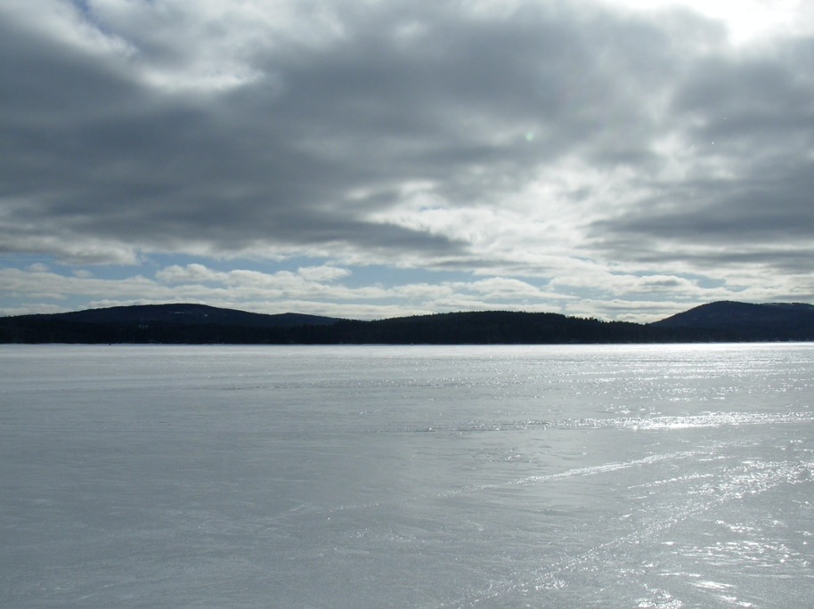

## One of many climate change indicators

- Global annual average surface temperature ✅
- Atmospheric concentrations of carbon dioxide ✅
- Ocean heat content 📈
- Global mean sea level 📈
- Global precipitation 📈
- Changing extent or mass of the cryosphere (ice) 🚀

  Source: World Meteorological Organization (WMO)

## What is ice-off

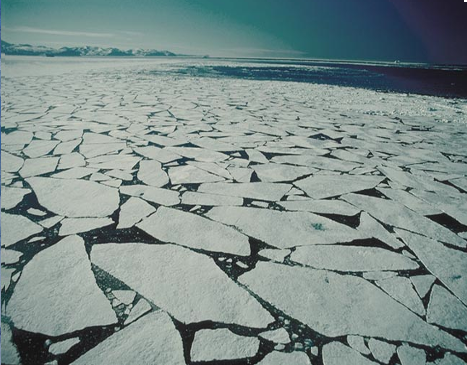

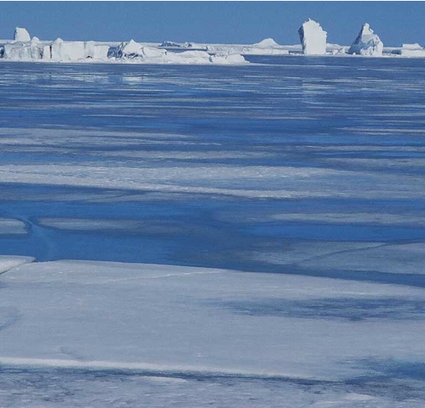

## How does ice melt?

- During the period of ice cover, snow on the ice both reflects sunlight and insulates the lake. With a thick snow layer, the lake neither gains nor loses heat to the atmosphere. The sediment at the bottom of the lake can actually be a small heat source to the water column over the winter, from stored heat over the summer.
- In the early spring, as the air warms and solar radiation increases, the snow melts, allowing light to penetrate the ice. The ice can act like glass in a greenhouse, allowing the lake water to warm.
- The ice begins to melt from the bottom, not the top.

## How does ice melt? (cont’d)

- When the ice erodes to a layer between 4 and 12 inches (10-30 cm) thick, it transforms into long vertical crystals called “candles.” These candles transmit light very well, so the ice starts to look black.

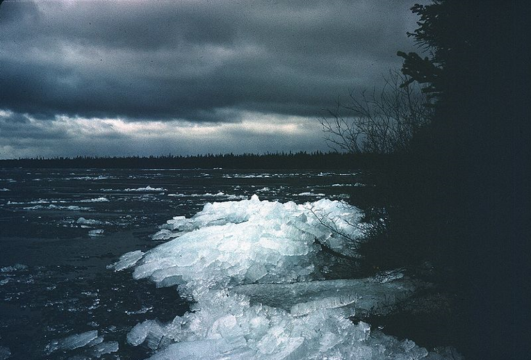

## How does ice melt? (cont’d)

- Warming continues, promoting melting of the ice from below because the light energy is being transferred to the water below the ice as heat. Meltwater fills in between the crystals, which begin breaking apart. The surface of the ice begins to appear grey.
- Finally, the ice thickness decreases further, allowing strong winds to break the surface of the ice apart. The candles will often collect on one side of the lake, making a tinkling sound as they pile up on the shore.

## Why are changes in ice-off dates important ecologically

- Warmer water -> less dissolved oxygen -> Bad for cold-water fish that need cold temps and lots of oxygen
- Less dissolved oxygen and anoxia -> Increase in P and reduced metals cycling from the sediment
- Warmer water -> Increased primary productivity (algal blooms)

## How do we measure ice-off?

Day-of-year = 0-365 (or 366) number defining the day since Jan 1 of that year.

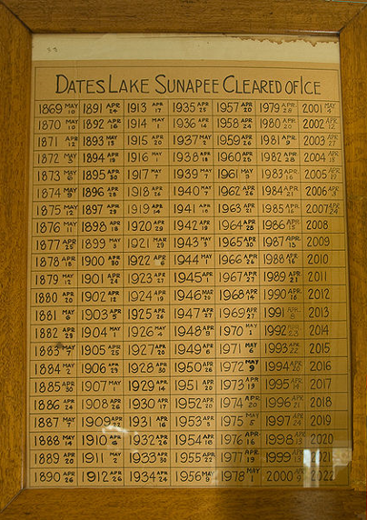

## How do we model ice-off?

- Linear regression
- y = m * x + b
- x is the “independent variable” (year)
- y is is the “dependent variable” (ice-off day of year; Julian day)

## Linear regression

- Linear regression
- y = m * x + b
- m is the “slope” (ice-off day / per year)
- b is the “intercept” (ice-off day when year = 0)

## Quality of model: coefficients

- Linear regression
- y = m * x + b
- We estimate coefficients (m and b) to build a model that relates year to ice-off day of year
- If m is different than 0, then we have a significant relationship

## Quality of model: R2

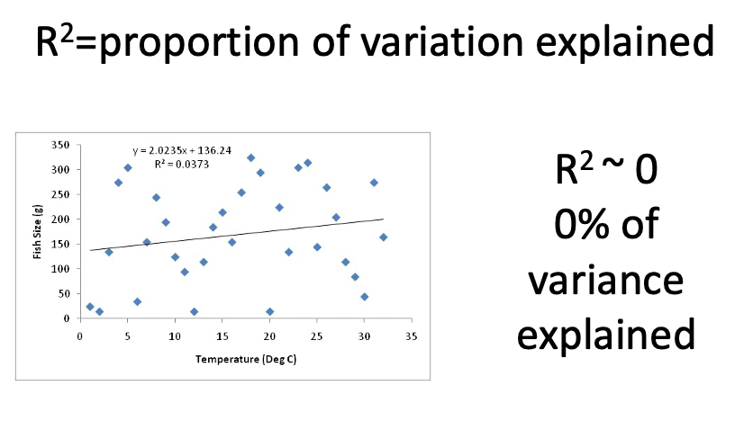

## Quality of model: R2

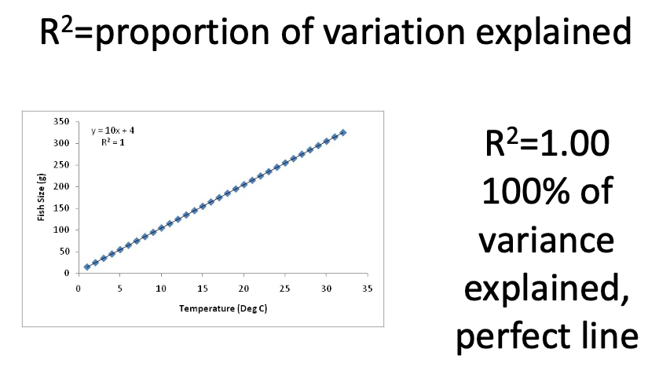

## Quality of model: R2

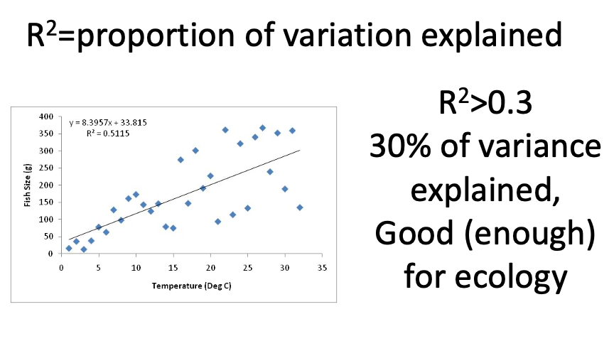

## Residuals

- If you subtract predicted line from the data you get the residuals
- Residuals should be centered on zero
- Residuals should be normally distributed (most values are close to zero)
- Residuals should be relatively small
- Residuals are small when R2 is near 1 and large when R2 is near 0.

## Linear regression in R

The following function runs a linear regression in R:

```
linear_model <- lm(dependent_variable ~ independent_variable1, data = df)
```

where

- The dependent variable (aka the predicted variable) is on the left side of the `~`
- Independent variables (aka predictors, covariates, or features) are on the right side of the `~`.
- Both variables need to be the in the data frame, `df`.
- `linear_model` is the result of the linear regression

## Key Questions

- How fast is the date that ice-off occurs changing over time for a focal lake?
- How well can we model ice-off and apply to future predictions?

## Data science skills

- Reading in data from excel files
- Linear regression
- Prediction
- Model assessment
- Improved figures: clear title and axis labels

## Assignment

- Your will be submitting *lake-ice-part1* for this assignment.

## Assignment reminders

- Accept (e.g., fork) assignment
- Clone your accepted assignment repo to your computer
- Work on assignment (many commits expected)
- Push assignment to GitHub (many times - this a backup)
- Final render of the document to HTML
- Commit and push HTML to GitHub
- Upload HTML to Canvas